# 문제 정의

- 문제 정의 / 기업가 정신 ( 역발상, 혁신, 도전, 사회적기여 등)에 입각한 해결방안 제시
- 분량은 3줄 이내

> 갈수록 증가하는 한국 이산화탄소 배출량에 관한 데이터를 통해 한국의 이산화탄소 배출량 증가에 대한 심각성을 파악하고 한국에서 사용하는 연료들이 각각 발생시키는 이산화탄소의 배출량에 관한 데이터를 통해 **어떤 연료의 사용을 줄여나가야 한국의 이산화탄소 배출량을 감소시켜 사회에 기여할 수 있을지에 대해서 알아본다.**

## 1. 데이터 수집

- 데이터 수집 과정을 제시하시오.
- 데이터 출처, 데이터 전처리 과정, 데이터 head() , tail() 출력

# # 데이터 출처

> 우리나라의 연도별 이산화탄소 배출량 및 증가량 및 연료 사용에 따른 이산화탄소 배출량  
> https://ourworldindata.org/co2/country/south-korea?country=~KOR

# # 데이터 전처리

> 우리나라의 이산화탄소 배출량 및 증가량에 관한 데이터 그리고 한국에서 사용하는 연료들이 각각 발생시키는 이산화탄소 배출량 데이터를 제외한 다른 국가들에 관한 데이터를 삭제했다.

# # head() , tail() 출력

> head()

```python
# The Emissions and Growth volume of carbon dioxide (1946-2018)
import pandas as pd
df1 = pd.read_csv('./data/ROK_CO2.csv')
df1.head()
```

|  | Entity | Code | Year | Annual CO2 growth (abs) | Annual CO2 emissions |
| --- | --- | --- | --- | --- | --- |
| 0 | South Korea | KOR | 1946 | 0.483648 | 0.487312 |
| 1 | South Korea | KOR | 1947 | 0.410368 | 0.897680 |
| 2 | South Korea | KOR | 1948 | 0.773104 | 1.670784 |
| 3 | South Korea | KOR | 1949 | 0.505632 | 2.176416 |
| 4 | South Korea | KOR | 1950 | 0.007328 | 2.183744 |

```python
# CO2 Emissions by fuel in South Korea (1945-2018)
import pandas as pd
df2 = pd.read_csv('./data/ROK_CO2_Fuel.csv')
df2.head()
```

|  | Entity | Code | Year | Gas (CDIAC & GCP (2020)) | Coal (CDIAC & GCP (2020)) | Oil (CDIAC & GCP (2020)) | Cement (CDIAC & GCP (2020)) |
| --- | --- | --- | --- | --- | --- | --- | --- |
| 0 | South Korea | KOR | 1945 | 0.0 | 0.000000 | 0.0 | 0.003664 |
| 1 | South Korea | KOR | 1946 | 0.0 | 0.479984 | 0.0 | 0.003664 |
| 2 | South Korea | KOR | 1947 | 0.0 | 0.886688 | 0.0 | 0.007328 |
| 3 | South Korea | KOR | 1948 | 0.0 | 1.663456 | 0.0 | 0.007328 |
| 4 | South Korea | KOR | 1949 | 0.0 | 2.165424 | 0.0 | 0.010992 |

> tail()

```python
# The Emissions and Growth volume of carbon dioxide (1946-2018)
import pandas as pd
df = pd.read_csv('./data/ROK_CO2.csv')
df.tail()
```

|  | Entity | Code | Year | Annual CO2 growth (abs) | Annual CO2 emissions |
| --- | --- | --- | --- | --- | --- |
| 68 | South Korea | KOR | 2014 | -4.992016 | 586.547863 |
| 69 | South Korea | KOR | 2015 | 8.846022 | 595.393885 |
| 70 | South Korea | KOR | 2016 | 22.566192 | 617.960077 |
| 71 | South Korea | KOR | 2017 | 22.624892 | 640.584969 |
| 72 | South Korea | KOR | 2018 | 18.202776 | 658.787745 |

```python
# CO2 Emissions by fuel in South Korea (1945-2018)
import pandas as pd
df2 = pd.read_csv('./data/ROK_CO2_Fuel.csv')
df2.tail()
```

|  | Entity | Code | Year | Gas (CDIAC & GCP (2020)) | Coal (CDIAC & GCP (2020)) | Oil (CDIAC & GCP (2020)) | Cement (CDIAC & GCP (2020)) |
| --- | --- | --- | --- | --- | --- | --- | --- |
| 69 | South Korea | KOR | 2014 | 98.7161 | 308.3678 | 156.1460 | 23.3179 |
| 70 | South Korea | KOR | 2015 | 90.0428 | 308.0178 | 172.8712 | 24.4621 |
| 71 | South Korea | KOR | 2016 | 94.5422 | 309.6923 | 188.1537 | 25.5719 |
| 72 | South Korea | KOR | 2017 | 98.7346 | 327.4663 | 189.0677 | 25.3164 |
| 73 | South Korea | KOR | 2018 | 111.0130 | 335.1934 | 187.4890 | 25.0924 |

## 2. 데이터 분석

- 데이터 분석 과정을 제시하시오.

> 우선, 갈수록 증가하는 **우리나라의 이산화탄소 배출량**에 관한 데이터를 찾아보기로 했다. 국내의 포털 사이트들 안에서 우리나라의 연간 이산화탄소 배출량에 관한 정보를 찾아봤지만 쉽사리 찾을 수 없었다. 그렇기 때문에 전 세계의 이산화탄소 배출량에 관한 데이터를 찾아 그곳에서 우리나라의 이산화탄소 배출량 데이터만을 추출해서 사용하기로 결정했다. 그렇게 우리나라의 이산화탄소 배출량에 관한 데이터를 찾아서 그래프로 나타내보니 뭔가 허전하다고 느껴져 우리나라의 이산화탄소 증가량에 관한 데이터도 찾아보게 되었다. 그렇게 찾은 우리나라의 이산화탄소 증가량 데이터 또한 그래프로 나타내니 한눈에 우리나라의 이산화탄소 배출량의 증가량을 파악할 수 있었다.

## 3. 시각화

- 분석 결과를 시각화하시오. 분석 결과 시각화 자료 1 ~ 2개

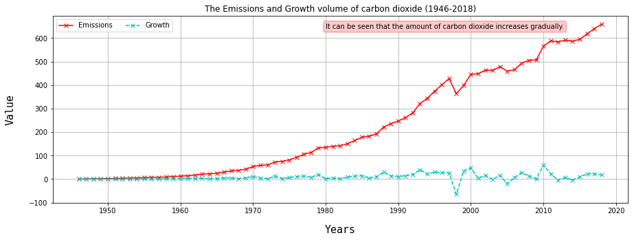

```python
# The Emissions and Growth volume of carbon dioxide (1946-2018)
import csv
import numpy as np
import matplotlib.pyplot as plt

f = open("./data/ROK_CO2.csv", encoding="utf-8")

data = csv.reader(f)
carbon_E = []
carbon_G = []
carbon_Y = []

next(data) # data의

box1 = {'boxstyle': 'round',
        'ec': (1.0, 0.5, 0.5),
        'fc': (1.0, 0.8, 0.8)}

for row in data :
        carbon_E.append(float(row[-1]))
        carbon_G.append(float(row[-2]))
        carbon_Y.append(float(row[-3]))

plt.figure(figsize=(15,5))
plt.title('The Emissions and Growth volume of carbon dioxide (1946-2018)')
plt.plot(carbon_Y, carbon_E,  'rx-', label="Emissions")
plt.plot(carbon_Y, carbon_G,  'cx--', label="Growth")
plt.grid(True)
plt.xlabel('Years', labelpad=15, fontdict={'family': 'monospace', 'weight': 'light', 'size': 15})
plt.ylabel('Value', labelpad=20, fontdict={'family': 'monospace', 'weight': 'light', 'size': 15})
plt.legend(loc='best', ncol=2)
plt.text(1980, 640, 'It can be seen that the amount of carbon dioxide increases gradually.', rotation=0, bbox=box1)
plt.show()
```

[figure not shown]

```python
# CO2 Emissions by fuel in South Korea (1945-2018)
import csv
import numpy as np
import matplotlib.pyplot as plt

f = open("./data/ROK_CO2_Fuel.csv", encoding="utf-8")

data = csv.reader(f)
gas = []
coal = []
oil = []
cement = []
year = []

next(data)

for row in data :
        gas.append(float(row[-1]))
        coal.append(float(row[-2]))
        oil.append(float(row[-3]))
        cement.append(float(row[-4]))
        year.append(float(row[-5]))

plt.figure(figsize=(15,5))
plt.title('CO2 Emissions by fuel in South Korea (1945-2018)')

plt.plot(year, gas,  'gx-', label="Gas")
plt.plot(year, coal,  'kx--', label="Coal")
plt.plot(year, oil,  'yx-.', label="Oil")
plt.plot(year, cement,  'cx:', label="Cement")

plt.grid(True)

plt.xlabel('Years', labelpad=15, fontdict={'family': 'monospace', 'weight': 'light', 'size': 15})
plt.ylabel('Value', labelpad=20, fontdict={'family': 'monospace', 'weight': 'light', 'size': 15})
plt.legend(loc='best', ncol=4)

plt.show()
```

## 4. AI 예측

예측을 제시하시오. 예측 시각화 자료 1 ~ 2개

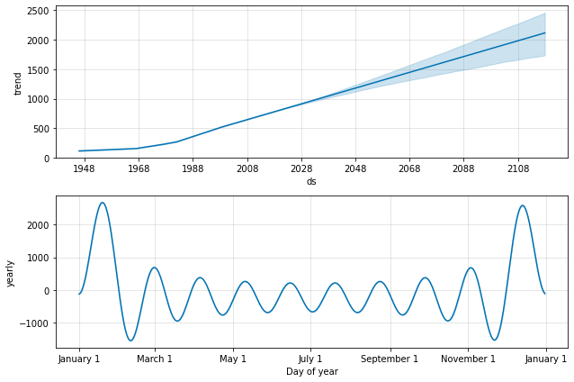

```python
from fbprophet import Prophet
import pandas as pd
df = pd.read_csv('./data/data2.csv')
m = Prophet(yearly_seasonality=True,weekly_seasonality=False,daily_seasonality=False)
m.fit(df)
future = m.make_future_dataframe(periods=36500)
f_carbon = m.predict(future)
fig= m.plot_components(f_carbon)
```

> 다음은 **AI 예측을 통해 만들어낸 한국의 이산화탄소 배출량 증가 예측 그래프**다. 이를 통해 이산화탄소 배출량은 갈수록 증가할 것이라는 것을 알 수 있다. 하지만 여기서 이산화탄소 배출량의 증가는 인간에게 큰 악영향을 끼칠 것이기 때문에 이산화탄소 배출량을 최소한시켜야 한다는 것 역시 알 수 있다.

- 문제 정의에 따른 분석 및 예측을 토대로 결론을 제시하시오. ( 기업가 정신에 입각한 해결방안 제시 )
- 분량은 10줄 이내

파일의 이름은 연번_학교명_팀명 으로 하고, ipynb 파일과 html 파일을 모두 제출 하시오. **(제출 파일은 2개)**  
※ html 파일은 File -> Download as .. -> HTML (.html) 을 선택하여 저장 하시오.